```python
import pandas as pd
import numpy as np
import matplotlib.pyplot as plt
```

### Задание 1. Загрузка данных

#### Загрузка CSV файла в DataFrame

```python
df = pd.read_csv('spotify_artist_streaming_2020_2025.csv')
```

```python
df
```

|  | track_id | track_name | artist_name | album_name | release_date | genre | duration_ms | popularity | danceability | energy | ... | popularity_category | loudness_category | key_name | mode_name | is_explicit_bool | release_quarter | is_weekend_release | log_stream_count | upbeat_score | artist_track_count |
| --- | --- | --- | --- | --- | --- | --- | --- | --- | --- | --- | --- | --- | --- | --- | --- | --- | --- | --- | --- | --- | --- |
| 0 | 346d85e2-ffde-41b3-854a-589ed880b91f | Storm | Ethereal | The Hollow Journeys | 2021-10-06 | Pop | 169594 | 47 | 0.6777 | 0.7949 | ... | Medium | Loud | A | Major | False | Q4 | False | 10.7492 | 0.6632 | 3232 |
| 1 | 12bc268a-363b-4f19-8fa8-0ced7ae1e462 | Silent | The Wolfs | Ancient Thunder | 2024-10-26 | K-Pop | 256755 | 26 | 0.9405 | 0.7163 | ... | Medium | Moderate | C# | Major | False | Q4 | True | 8.5895 | 0.7615 | 20 |
| 2 | 30d627d9-878d-4bb3-be59-71feb6ed4f3f | Shattered Lines | LolaOre | Twisted Harbors | 2022-11-12 | Punk | 170212 | 46 | 0.6853 | 0.9500 | ... | Medium | Loud | E | Major | False | Q4 | True | 12.2935 | 0.7828 | 199 |
| 3 | 85501bb9-d221-4339-9e2e-29b1b3daff0a | Breaking Roses | Clay Black | The Blinding Letters | 2020-06-22 | Pop | 181250 | 4 | 0.7817 | 0.6943 | ... | Low | Moderate | F# | Major | False | Q2 | False | 8.5658 | 0.6778 | 693 |
| 4 | 7bf92bd2-c6fe-4869-a90e-242bb8bbe7a3 | Lines | Knot Hart | The Cosmic Letters | 2024-01-22 | Latin | 160894 | 27 | 0.7200 | 0.4958 | ... | Medium | Moderate | C# | Major | False | Q1 | False | 10.2191 | 0.5494 | 12111 |
| ... | ... | ... | ... | ... | ... | ... | ... | ... | ... | ... | ... | ... | ... | ... | ... | ... | ... | ... | ... | ... | ... |
| 49995 | 38913908-e3ab-42a2-9a97-2d1847c21e3b | Flames | Luna Ink | The Shattered Tapes | 2025-02-27 | Hip-Hop | 249380 | 6 | 0.7338 | 0.8172 | ... | Low | Loud | C# | Major | False | Q1 | False | 6.2005 | 0.7545 | 577 |
| 49996 | 83653402-ca85-4583-b7ec-13ab3e82888e | Love | Knot Hart | Young II | 2021-07-25 | Folk | 176329 | 22 | 0.5547 | 0.0000 | ... | Low | Quiet | A# | Minor | True | Q3 | True | 9.1916 | 0.3292 | 12111 |
| 49997 | 4398dd33-ecfc-4c1a-ab9e-248f38082318 | The Waves | Jasper Jade | The Burning Journeys | 2023-12-24 | Pop | 202472 | 5 | 0.6558 | 0.8805 | ... | Low | Moderate | G | Major | True | Q4 | True | 7.8200 | 0.6794 | 181 |
| 49998 | 07c673e7-39a5-4c28-8789-163ae5f17f3f | Flying Eyes | ElaraRain | Frequencies | 2020-08-17 | Rock | 172542 | 81 | 0.5979 | 0.6252 | ... | Very High | Moderate | F# | Minor | False | Q3 | False | 15.1911 | 0.5622 | 1111 |
| 49999 | 888e233c-e7fd-4c0d-af8a-3cd98345a64e | Roads | Edge Brooks | Wicked III | 2020-11-19 | Hip-Hop | 198469 | 27 | 0.9388 | 0.6830 | ... | Medium | Moderate | G# | Minor | True | Q4 | False | 9.3957 | 0.7795 | 65 |

50000 rows × 33 columns

### Задание 2. Первичное знакомство с датасетом

```python
df.head(10)
```

|  | track_id | track_name | artist_name | album_name | release_date | genre | duration_ms | popularity | danceability | energy | ... | popularity_category | loudness_category | key_name | mode_name | is_explicit_bool | release_quarter | is_weekend_release | log_stream_count | upbeat_score | artist_track_count |
| --- | --- | --- | --- | --- | --- | --- | --- | --- | --- | --- | --- | --- | --- | --- | --- | --- | --- | --- | --- | --- | --- |
| 0 | 346d85e2-ffde-41b3-854a-589ed880b91f | Storm | Ethereal | The Hollow Journeys | 2021-10-06 | Pop | 169594 | 47 | 0.6777 | 0.7949 | ... | Medium | Loud | A | Major | False | Q4 | False | 10.7492 | 0.6632 | 3232 |
| 1 | 12bc268a-363b-4f19-8fa8-0ced7ae1e462 | Silent | The Wolfs | Ancient Thunder | 2024-10-26 | K-Pop | 256755 | 26 | 0.9405 | 0.7163 | ... | Medium | Moderate | C# | Major | False | Q4 | True | 8.5895 | 0.7615 | 20 |
| 2 | 30d627d9-878d-4bb3-be59-71feb6ed4f3f | Shattered Lines | LolaOre | Twisted Harbors | 2022-11-12 | Punk | 170212 | 46 | 0.6853 | 0.9500 | ... | Medium | Loud | E | Major | False | Q4 | True | 12.2935 | 0.7828 | 199 |
| 3 | 85501bb9-d221-4339-9e2e-29b1b3daff0a | Breaking Roses | Clay Black | The Blinding Letters | 2020-06-22 | Pop | 181250 | 4 | 0.7817 | 0.6943 | ... | Low | Moderate | F# | Major | False | Q2 | False | 8.5658 | 0.6778 | 693 |
| 4 | 7bf92bd2-c6fe-4869-a90e-242bb8bbe7a3 | Lines | Knot Hart | The Cosmic Letters | 2024-01-22 | Latin | 160894 | 27 | 0.7200 | 0.4958 | ... | Medium | Moderate | C# | Major | False | Q1 | False | 10.2191 | 0.5494 | 12111 |
| 5 | e4a536ca-c6d4-4bad-97b5-d5e7b85c49e2 | Wild Doors | Knot Hart | Jagged Gardens | 2021-04-12 | R&B | 198179 | 28 | 0.6538 | 0.3732 | ... | Medium | Moderate | G# | Major | False | Q2 | False | 9.8292 | 0.4586 | 12111 |
| 6 | 305b4f13-b2ac-47e9-a6f2-d0c15934f8b6 | Skies | Knot Hart | The Ancient Tapes | 2025-07-16 | R&B | 251330 | 18 | 0.7399 | 0.4000 | ... | Low | Moderate | G | Minor | False | Q3 | False | 9.6072 | 0.5475 | 12111 |
| 7 | 83c3a6be-6066-449a-a339-19afcde7cfb3 | Wild | Blaze Project | Crystal | 2023-12-12 | Classical | 208198 | 15 | 0.1730 | 0.3085 | ... | Low | Moderate | G# | Major | True | Q4 | False | 6.9745 | 0.2482 | 53 |
| 8 | 437961fc-9ccd-4c86-8eb7-e96b6d2dc5c8 | Neon Oceans | Clay Black | Broken V | 2020-06-17 | Pop | 254751 | 23 | 0.6838 | 0.5026 | ... | Low | Moderate | G | Minor | True | Q2 | False | 8.3301 | 0.5249 | 693 |
| 9 | 53df0c89-adc4-48b7-94e3-111e348cb17b | Eternal Angels | Phantasm | The Kind Notes | 2020-06-09 | Trap | 310076 | 39 | 0.5759 | 0.8349 | ... | Medium | Moderate | D# | Minor | False | Q2 | False | 12.1223 | 0.6488 | 242 |

10 rows × 33 columns

#### Первые 10 строк таблицы

```python
df.shape
```

```
(50000, 33)
```

#### Количество строк и столбцов

```python
df.columns
```

```
Index(['track_id', 'track_name', 'artist_name', 'album_name', 'release_date',
       'genre', 'duration_ms', 'popularity', 'danceability', 'energy', 'key',
       'loudness', 'mode', 'instrumentalness', 'tempo', 'stream_count',
       'country', 'explicit', 'label', 'release_year', 'release_month',
       'release_day_of_week', 'duration_minutes', 'popularity_category',
       'loudness_category', 'key_name', 'mode_name', 'is_explicit_bool',
       'release_quarter', 'is_weekend_release', 'log_stream_count',
       'upbeat_score', 'artist_track_count'],
      dtype='object')
```

#### Названия всех столбцов

```python
df.info()
```

```
<class 'pandas.core.frame.DataFrame'>
RangeIndex: 50000 entries, 0 to 49999
Data columns (total 33 columns):
 #   Column               Non-Null Count  Dtype
---  ------               --------------  -----
 0   track_id             50000 non-null  object
 1   track_name           50000 non-null  object
 2   artist_name          50000 non-null  object
 3   album_name           50000 non-null  object
 4   release_date         50000 non-null  object
 5   genre                50000 non-null  object
 6   duration_ms          50000 non-null  int64
 7   popularity           50000 non-null  int64
 8   danceability         50000 non-null  float64
 9   energy               50000 non-null  float64
```

[output cut: 25 more lines]

#### Типы данных столбцов

### Задание 3. Сортировка данных

```python
top_10 = df.sort_values(by='stream_count', ascending=False).head(10)
top_10[['artist_name', 'genre', 'stream_count']]  # или какие у вас будут названия
```

|  | artist_name | genre | stream_count |
| --- | --- | --- | --- |
| 1528 | Grove Nova | Alternative | 43345015 |
| 36998 | Flora Quinn | Rock | 26635547 |
| 42813 | Ethereal | Pop | 26314312 |
| 21643 | SethStone | Metal | 20408155 |
| 49193 | IsleEyre | Pop | 19265301 |
| 26622 | Dean System | Hip-Hop | 17238449 |
| 45015 | Rocco Ore | R&B | 15776187 |
| 39012 | Knot Hart | R&B | 14545933 |
| 29091 | The Inks | Pop | 14507867 |
| 13635 | Prism Hart | R&B | 14367106 |

#### 10 треков с максимальным количеством прослушиваний

**Ответ:** Среди самых прослушиваемых треков встречаются популярные исполнители и жанры (см. таблицу выше)

### Задание 4. Фильтрация

```python
tracks_after_2024 = df[df['release_year'] > 2024]
tracks_after_2024
```

|  | track_id | track_name | artist_name | album_name | release_date | genre | duration_ms | popularity | danceability | energy | ... | popularity_category | loudness_category | key_name | mode_name | is_explicit_bool | release_quarter | is_weekend_release | log_stream_count | upbeat_score | artist_track_count |
| --- | --- | --- | --- | --- | --- | --- | --- | --- | --- | --- | --- | --- | --- | --- | --- | --- | --- | --- | --- | --- | --- |
| 6 | 305b4f13-b2ac-47e9-a6f2-d0c15934f8b6 | Skies | Knot Hart | The Ancient Tapes | 2025-07-16 | R&B | 251330 | 18 | 0.7399 | 0.4000 | ... | Low | Moderate | G | Minor | False | Q3 | False | 9.6072 | 0.5475 | 12111 |
| 14 | 7e9be073-392f-4592-bea4-8b670368087c | The Roads | Knot Hart | Oceans | 2025-11-26 | R&B | 253544 | 5 | 0.4676 | 0.4455 | ... | Low | Moderate | C | Minor | False | Q4 | False | 6.7867 | 0.4417 | 12111 |
| 17 | 6a12365c-81bd-424b-884b-2bbcc5ff620a | Liquid Streets | ElaraRain | Invisible Waves | 2025-05-22 | Pop | 199052 | 25 | 0.5858 | 0.6315 | ... | Medium | Moderate | F | Major | False | Q2 | False | 9.4172 | 0.5639 | 1111 |
| 18 | cee75c87-13b6-4af0-a17d-830be6008414 | Broken Ghosts | Sterling Zen | Blinding Shadows | 2025-01-21 | Hip-Hop | 171193 | 40 | 0.8733 | 0.7090 | ... | Medium | Loud | F | Minor | False | Q1 | False | 11.7608 | 0.7445 | 2268 |
| 24 | cfc19120-16c7-4e8c-a99e-e617973c451a | The Tears | Sterling Zen | Sacred Rain | 2025-03-18 | Folk | 233446 | 33 | 0.3071 | 0.3266 | ... | Medium | Moderate | B | Major | True | Q1 | False | 10.7252 | 0.3225 | 2268 |
| ... | ... | ... | ... | ... | ... | ... | ... | ... | ... | ... | ... | ... | ... | ... | ... | ... | ... | ... | ... | ... | ... |
| 49970 | b9cb5000-702d-449b-91ea-5bfbf0eaacc8 | Twisted Empty Floors | IsleEyre | Skies | 2025-04-09 | Pop | 278833 | 25 | 0.6097 | 0.8090 | ... | Medium | Moderate | D# | Minor | False | Q2 | False | 10.7419 | 0.6625 | 5271 |
| 49976 | 609e15e2-1385-45ff-859e-bdfb0eee7a61 | Blinding Lines | ValeGlass | Velvet Bones | 2025-11-30 | Latin | 216171 | 31 | 0.7654 | 0.6896 | ... | Medium | Loud | F | Major | True | Q4 | True | 11.6265 | 0.6584 | 981 |
| 49981 | 32a33aad-48d1-4f39-914d-374e3c9e8eb2 | Ancient Night | Knot Hart | Lost Winds | 2025-10-31 | R&B | 178343 | 11 | 0.6109 | 0.6311 | ... | Low | Loud | C | Major | False | Q4 | False | 7.2392 | 0.5838 | 12111 |
| 49987 | 7deb5a56-18ba-420e-acbd-167adaac4c4a | Dreams | Rocco Ore | Crystal | 2025-09-15 | R&B | 162654 | 16 | 0.6925 | 0.3973 | ... | Low | Moderate | C# | Major | False | Q3 | False | 7.8883 | 0.4859 | 1709 |
| 49995 | 38913908-e3ab-42a2-9a97-2d1847c21e3b | Flames | Luna Ink | The Shattered Tapes | 2025-02-27 | Hip-Hop | 249380 | 6 | 0.7338 | 0.8172 | ... | Low | Loud | C# | Major | False | Q1 | False | 6.2005 | 0.7545 | 577 |

8318 rows × 33 columns

#### Треки после 2024 года

### Задание 5. Основные статистические показатели

```python
mean_popularity = df['popularity'].mean()
median_popularity = df['popularity'].median()
```

#### Среднее и медиана для popularity

```python
mean_popularity
median_popularity
```

```
26.0
```

#### Показываем результаты

```python
df['popularity'].describe()
```

```
count    50000.000000
mean        28.136820
std         15.999501
min          0.000000
25%         16.000000
50%         26.000000
75%         39.000000
max         92.000000
Name: popularity, dtype: float64
```

#### Минимум, максимум и стандартное отклонение для popularity

### Задание 6. Мода

```python
df['genre'].mode()
```

```
0    R&B
Name: genre, dtype: object
```

#### Мода для столбца genre

```python
df['release_year'].mode()
```

```
0    2024
Name: release_year, dtype: int64
```

#### Мода для столбца release_year

### Задание 7. Гистограмма

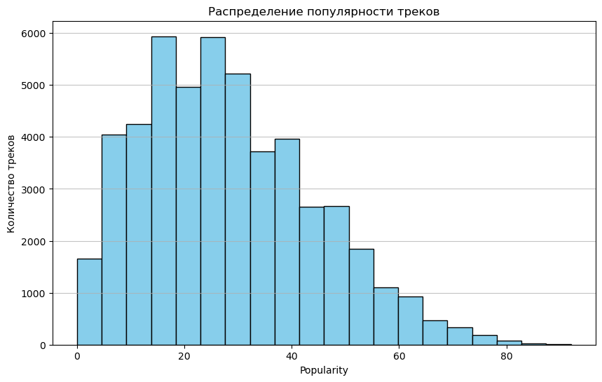

```python
plt.figure(figsize=(10, 6))
plt.hist(df['popularity'], bins=20, color='skyblue', edgecolor='black')
plt.title('Распределение популярности треков')
plt.xlabel('Popularity')
plt.ylabel('Количество треков')
plt.grid(axis='y', alpha=0.75)
plt.show()
```

### Задание 8. Итоговый вывод и контрольные вопросы

**Итоговый вывод:**  
В ходе практической работы были закреплены навыки первичного анализа данных с использованием библиотеки Pandas. Мы успешно загрузили датасет, изучили его структуру, отсортировали данные по количеству прослушиваний, отфильтровали треки по году выпуска, рассчитали ключевые статистические метрики (среднее, медиану, моду, стандартное отклонение) и визуализировали распределение популярности с помощью гистограммы. Полученные навыки позволяют проводить базовый разведочный анализ данных (EDA).

**Ответы на контрольные вопросы:**

1. **Что такое DataFrame?**  
   Это двумерная табличная структура данных в библиотеке Pandas, состоящая из строк и столбцов, где каждый столбец может иметь свой тип данных.
2. **Что такое признак (Feature)?**  
   Это отдельный столбец в датасете, который описывает определенную характеристику или свойство объекта наблюдения (например, `popularity`, `genre`, `release_year`).
3. **Чем среднее арифметическое отличается от медианы?**  
   Среднее арифметическое чувствительно к экстремальным значениям (выбросам), так как учитывает все числа при сложении. Медиана показывает центральное значение в упорядоченном ряду и не искажается выбросами.
4. **Что показывает гистограмма?**  
   Гистограмма показывает распределение частот данных, позволяя визуально оценить форму распределения, центр, разброс и наличие аномальных значений (выбросов).
5. **Для чего нужна фильтрация данных?**  
   Фильтрация нужна для отбора подмножества данных, удовлетворяющих определенным условиям, чтобы анализировать только релевантные для конкретной задачи записи (например, только новые треки или только определенный жанр).